# Envinformatics - Using Obsidian in Mind Mapping

Zettelkasten

Zotero

Obsidian

Mind Mapping

Tools and workflows for Mind Mapping projects during research.

Author

Me

Published

July 13, 2023

### What is a Mind Map?

A mind map is a visual representation of an idea that uses nodes/points and lines to connect ideas together. The mind map primarily uses text inside of a node/point connected by lines. You can use color, images, line style, line weight, symbols, and other things to visualize your idea.

### Why should I use a Mind Map?

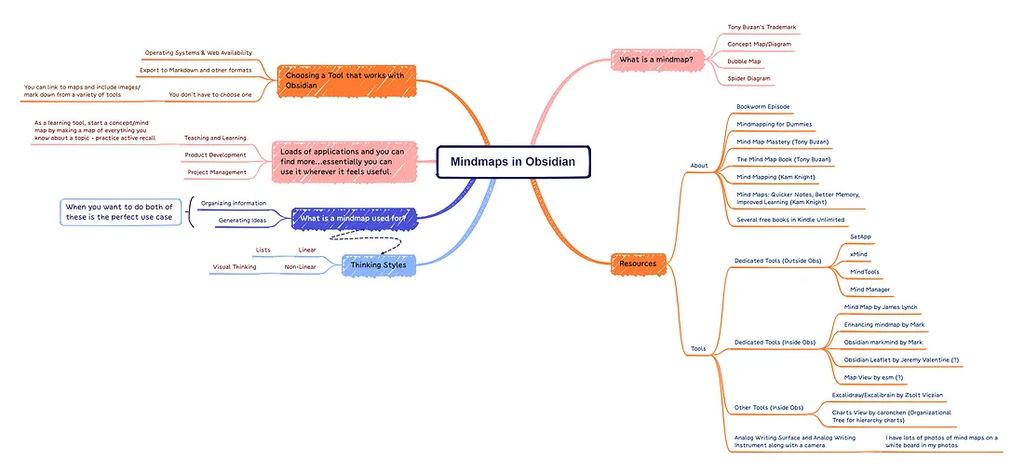

Text

When you have many lists, a mind map adds an extra dimension to lists. For example, I started this article as that mind map pictured above. Sometimes I start articles as outlines. Obviously, writing an article on mind maps must start with a mind map. mind maps work best for me in two broad use cases:

```
- Generating new ideas
- Organizing information
```

#### Generating Ideas

As I’ve already shown, you can develop the structure of a writing or other creative project with a mind map. I love mind maps for any sort of project work. When I am going to start a new project I almost always start with a mind map of ideas I have about what I know about the project and what I need to find out about the project.

I also think mind maps are perfect for planning activities when they aren’t “linear”. For example, my annual planning I do as a mind map first where I write out what I know will happen in that year and then brainstorm things I want to do in the year. I then take what I generate in the mind map and can place it on the calendar.

#### Organizing Information

When I am learning something new — particularly through reading — I very often start with a mind map. I love the Blank Sheet Method from Farnam Street. If I am starting a book on a topic I’m actively trying to learn, I’ll use a version of this method for my learning sessions. Each starts with a mind map about what I know about the topic and then as I’m reading, watching videos, or consuming other educational content, I’ll add to my mind map in a different color.

### Use Mind Maps in Obsidian

[output not shown]

[Mind Mapping in Obsidian Canvas](https://www.youtube.com/watch?v=eHI-Szjpafk)